# Lab 9: Using exploratory analysis and arules

2020-08-26 19:13:36

Chapter 17 of the textbook (“Hi Ho, Hi Ho – Data Mining We Go”) introduces association rules mining – a very flexible and easy to understand form of unsupervised machine learning. Association rules mining is also sometimes called market basket analysis, and indeed the chapter works an example that focuses on groceries. Yet association rules mining can be applied to a variety of types of data, basically any data set where you have a list of “containers” and each container has a list of stuff inside it. Association rules mining looks for commonalities across these containers – what are the combinations of items that frequently occur together.

If you think about it for a minute, you might see that this idea applies to documents (e.g., emails or web pages) and the words that appear in them. Each document can be thought of as a container of words, and within each container certain combinations of words may appear together. In a previous chapter, we explored this idea by creating a “termdocument” matrix. In this exercise, we are going to apply association rules mining to a term-document matrix.

You can create and/or find all of the code you need to accomplish these steps:

- There is a nice, manageable term-document matrix that Yanchang Zhao has created based on a set of tweets about data mining that he extracted: http://www.rdatamining.com/data/termDocMatrix.rdata
  - If for some reason hat link doesn’t work, you should visit this page and download the file entitled “termDocMatrix.rdata” onto your computer: http://www.rdatamining.com/data
  - As you have guessed from the file extension, this is a dataset that is already prepared for opening in R. Run R-Studio on your laptop and use the Open File command to load this file. After answering the confirmation message affirmatively, you will find that a data object called “termDocMatrix” appears in your environment window. Inspect this data object.

## Step 1: Load data

```r
# read in the data
  load("~/Dropbox/Applied Data Science (IST 687)/Datasets/termDocMatrix.rdata")
  # store the data in a new object called "Data"
  Data <- termDocMatrix

  # sets values greater than 1 to one for simple rule mining
  Data[Data>1] <- 1

  # check the first 5 rows of the matrix
  head(Data,5)
```

```
##               Docs
## Terms          1 2 3 4 5 6 7 8 9 10 11 12 13 14 15 16 17 18 19 20 21 22 23
##   analysis     0 0 0 0 0 0 0 0 0  0  0  0  0  0  0  1  0  1  1  1  1  0  0
##   applications 0 0 0 0 0 0 0 0 0  0  0  0  0  0  0  0  0  0  0  0  0  0  0
##   code         0 0 0 0 0 0 0 0 0  0  0  0  0  0  0  0  0  0  0  0  0  0  0
##   computing    0 0 1 1 0 1 1 1 1  1  0  1  0  0  0  0  0  0  0  0  0  0  0
##   data         1 1 0 0 1 0 0 0 0  0  1  1  1  1  1  0  1  0  0  0  0  0  0
##               Docs
## Terms          24 25 26 27 28 29 30 31 32 33 34 35 36 37 38 39 40 41 42 43
##   analysis      1  0  0  1  1  1  1  0  0  0  0  0  0  0  1  0  0  0  0  0
##   applications  0  0  0  0  0  0  0  0  0  0  0  1  0  0  0  0  0  0  1  0
##   code          0  1  0  0  0  0  0  0  0  0  0  0  0  0  0  0  0  0  0  0
##   computing     0  0  0  0  0  0  0  0  0  0  0  0  0  0  0  0  0  1  0  0
##   data          0  0  0  0  1  0  0  0  1  0  0  1  1  0  0  0  0  0  1  0
##               Docs
## Terms          44 45 46 47 48 49 50 51 52 53 54 55 56 57 58 59 60 61 62 63
##   analysis      0  0  0  0  0  0  0  0  0  0  0  0  0  0  0  0  0  0  0  0
##   applications  0  0  1  0  0  0  0  0  0  0  1  0  0  0  0  0  0  0  0  0
##   code          0  0  0  0  0  0  0  0  0  0  0  0  0  0  0  0  0  0  0  0
##   computing     0  0  0  0  0  0  0  0  0  0  0  0  0  1  0  0  0  0  0  0
##   data          0  1  1  1  0  0  1  0  0  0  1  1  0  0  1  1  0  1  0  1
##               Docs
## Terms          64 65 66 67 68 69 70 71 72 73 74 75 76 77 78 79 80 81 82 83
##   analysis      0  0  0  0  0  1  0  0  0  0  0  0  0  0  0  0  1  0  0  0
##   applications  0  0  0  0  0  0  0  0  0  0  0  0  0  0  0  0  0  0  0  1
##   code          0  0  0  0  0  0  0  0  0  0  0  0  0  0  0  0  0  0  1  0
##   computing     0  0  0  0  0  0  0  0  0  0  0  0  0  0  0  0  0  0  0  0
##   data          0  1  1  0  0  0  1  0  0  0  1  0  0  0  1  0  0  0  0  1
##               Docs
## Terms          84 85 86 87 88 89 90 91 92 93 94 95 96 97 98 99 100 101 102
##   analysis      0  0  0  0  0  0  0  0  0  0  1  0  0  1  0  0   0   1   0
##   applications  0  0  0  0  1  1  0  0  0  0  0  0  0  0  0  0   0   0   0
##   code          0  0  0  0  0  0  0  0  0  0  0  0  0  0  0  0   0   0   0
##   computing     0  0  0  0  0  0  0  0  0  0  0  0  0  0  0  0   0   0   0
##   data          0  0  0  0  1  0  1  0  0  1  0  0  0  1  0  0   0   0   0
##               Docs
## Terms          103 104 105 106 107 108 109 110 111 112 113 114 115 116 117
##   analysis       0   0   0   0   0   1   0   0   0   0   0   0   0   0   0
##   applications   0   0   0   0   0   0   0   0   0   0   0   0   0   0   0
##   code           0   0   1   0   0   1   0   0   0   1   0   0   0   0   0
```

[output cut: 8 more lines]

```
##   data           0   1   0   1   0   1   1   0   0   0   0   0   0   0   0
##               Docs
## Terms          133 134 135 136 137 138 139 140 141 142 143 144 145 146 147
##   analysis       0   0   0   0   0   0   0   0   0   0   0   0   0   1   0
##   applications   0   0   0   0   0   0   0   0   0   0   0   0   0   0   0
##   code           0   0   0   1   0   0   0   0   0   0   0   0   0   0   0
##   computing      0   0   0   0   0   0   0   0   0   0   0   0   0   0   0
##   data           1   0   0   0   0   1   1   0   0   0   1   0   1   1   0
##               Docs
## Terms          148 149 150 151 152 153 154
##   analysis       0   0   0   0   0   1   0
##   applications   0   0   0   0   0   0   1
##   code           0   0   0   0   0   0   0
##   computing      0   0   0   0   0   0   0
##   data           0   1   0   1   1   0   1
```

- For association rules mining (and more specifically the apriori() command) to work properly, you want items in containers/baskets to be your columns and the rows to be your containers. You will find that this data object is set up the opposite way: It has the terms as rows and the documents as columns. You will need to transpose the data set, and fortunately R has a command to do that very easily. Do some research to find that command and how to use it. Then transpose your data set and place it in a new data object.

## Step 2: Transpose the matrix

```r
  df <- t(Data)
  # check the first 5 rows to make sure the transpose was done correctly
  head(df,5)
```

```
##     Terms
## Docs analysis applications code computing data examples introduction
##    1        0            0    0         0    1        0            0
##    2        0            0    0         0    1        0            0
##    3        0            0    0         1    0        0            0
##    4        0            0    0         1    0        0            0
##    5        0            0    0         0    1        0            0
##     Terms
## Docs mining network package parallel positions postdoctoral r research
##    1      0       0       0        0         1            0 0        0
##    2      0       0       0        0         1            0 0        1
##    3      0       0       0        1         0            0 1        0
##    4      0       0       1        1         0            0 1        0
##    5      0       0       1        0         0            0 1        0
##     Terms
## Docs series slides social time tutorial users
##    1      0      0      0    0        0     0
##    2      0      0      0    0        0     0
##    3      0      0      0    0        0     0
##    4      0      0      0    0        1     1
##    5      0      0      0    0        0     1
```

```r
  # coerce df to a transaction class. as() is an arules function
  d <- as(df, "transactions")
```

- Next, apply all of the techniques you learning from chapter 17. This means that you will have to load the arules package, run apriori(), set the parameters correctly, inspect the results, visualize the results using the arulesViz package, and make sense out of what you find. You should set your parameters so you generate at least 20 rules.
  - There are many other analysis which offer other insights in arules(). Check them here: [Association Mining with R](http://r-statistics.co/Association-Mining-With-R.html) and [arules](https://rdrr.io/cran/arules/f/inst/doc/arules.pdf)

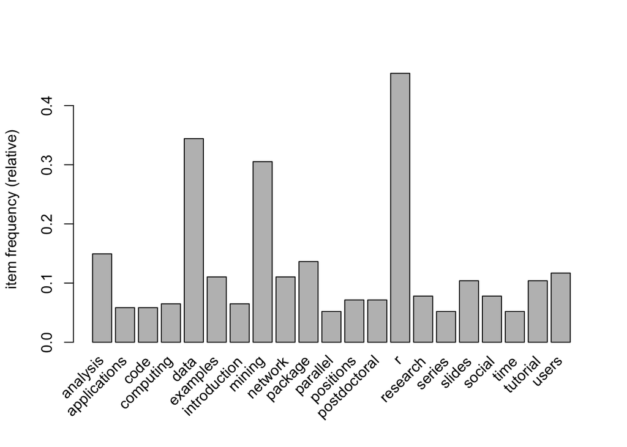

```r
itemFrequencyPlot(d)
```

- At the end of your code file for this exercise, write a few sentences interpreting the results of this analysis and describing how this technique might be valuable in making sense out of large sets of documents (e.g., emails).